# Análisis, modelado y predicción de la serie CO2

Francisco Aragón Royón

26 de enero de 2017

#### Objetivo

El objetivo de este documento es el análisis y modelado junto con la predicción de la serie temporal CO2.

#### Análisis previo de la serie

Para ello, en primer lugar se cargan las librerías necesarias junto con los datos, para posteriormente transformar estos datos “brutos” en una serie temporal mediante el comando *ts* y mostrar la gráfica de secuencia de la serie mediante el comando *plot (que internamente llamará al comando plot.ts*. Un análisis previo de los datos revela que las observaciones han sido tomadas mensualmente, sin anomalías aparentes en los datos, luego la frecuencia de la serie se establece en 12.

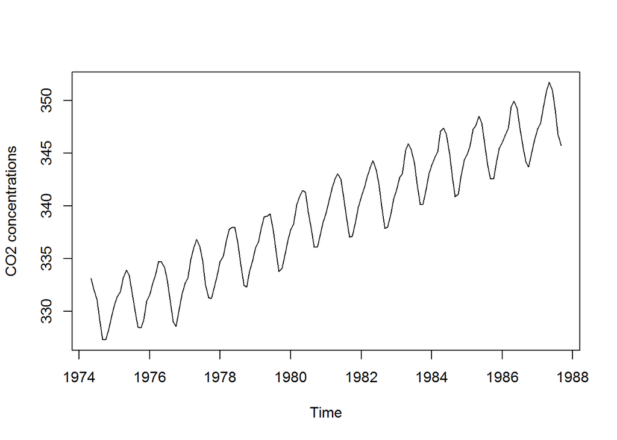

```r
setwd("C:/Users/Kuko/Desktop/Series temporales/Pruebas R")

# Se cargan las librerias necesarias
library(tseries)
library(forecast)

# Se lee el conjunto de datos
co2 <- read.csv("co2.csv",header=TRUE,sep=";")

# Se transforman los datos brutos en una serie temporal
tsco2 <- ts(co2$CO2, start=c(co2$Year[1],co2$Month[1]),frequency = 12)

# Se pinta la serie temporal
plot(tsco2,xlab="Time",ylab="CO2 concentrations")
```

Una vez pintada la serie temporal se puede hacer una valoración a simple vista de sus características. Así, se aprecia que la serie presenta una tendencia ascendente (luego no es estacionaria en media) y que la serie presenta estacionalidad. Con esto ya es suficiente para afirmar que la serie *no es estacionaria*. También se puede observar que la serie parece estacionaria en cuando a la varianza, ya que no se aprecia gran variabilidad, luego no será necesario realizar transformaciones previas para estabilizarla (logaritmos o Box-Cox). Para cerciorarmos aún más de que la serie no es estacionaria, vamos a pintar la gráfica de su función de autocorrelación:

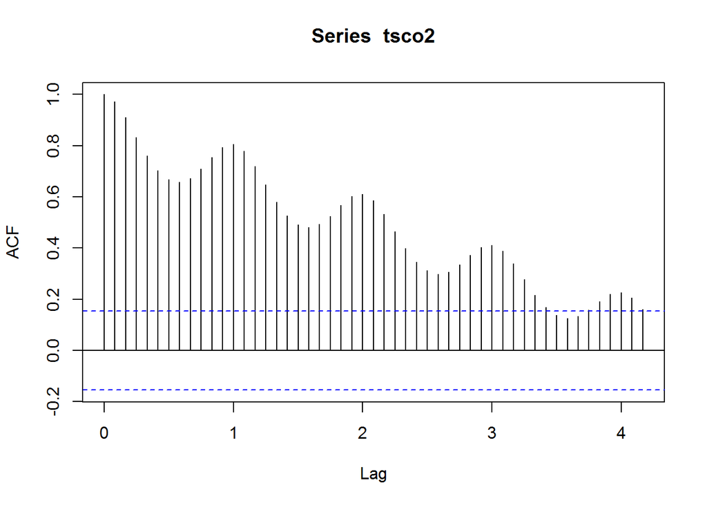

```r
# Pinta el resultados de la función de autocorrelación simple
plot(acf(tsco2,lag.max=50))
```

En esta gráfica se ve claramente como la serie no es estacionaria ya que el valor de la función de autocorrelación no decae de manera exponencial a medida que aumentan los rezagos en el tiempo. También se puede apreciar la existencia de la componente estacional, con un periodo de 12. Todas estas componentes se pueden ver de manera separada y clara usando las funciones R *decompose* y *stl*:

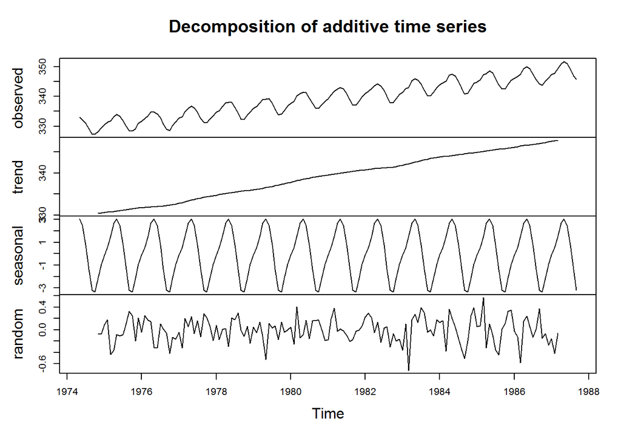

```r
# Descompone la serie mediante medias móviles
decompose.tsco2 <- decompose(tsco2, type="additive")
plot(decompose.tsco2)
```

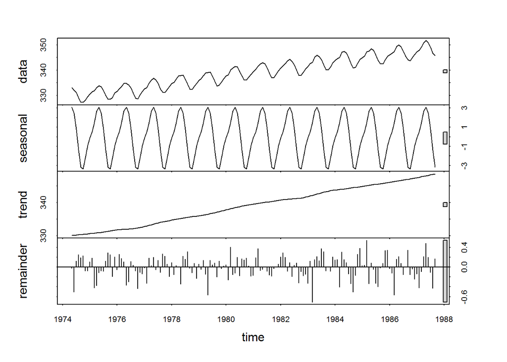

```r
# Descompone la serie median loess
stl.tsco2 <- stl(tsco2, s.window="periodic")
plot(stl.tsco2)
```

#### Modelado de la serie

El análisis previo de la serie nos ha revelado que hay que modelar y eliminar la tendencia y estacionalidad de la serie para que pueda ser estacionaria. Puesto que el modelo que vamos a utilizar es un modelo ARIMA, vamos a ver si mediante diferenciación regular y estacional podemos hacer que la serie resultante sea estacionaria. A priori con un orden en cada diferenciación podría ser suficiente, pero vamos a ver que nos dicen las funciones *ndiffs* y *nsdiffs*, que calculan cada una el número de diferenciaciones regulares y estacionales respectivamente que se necesitan llevar a cabo para que la serie sea estacionaria:

```r
# Calculan el número de diferencia necesarias para que la serie sea estacionaria
ndiffs(tsco2)
```

```
## [1] 1
```

```r
nsdiffs(tsco2)
```

```
## [1] 1
```

Ambos cálculos nos arrojan que se necesita de una diferenciación regular y otra estacional para hacer la serie estacionaria. Luego vamos a comenzar realizando una diferenciación regular de orden 1 para eliminar la tendencia:

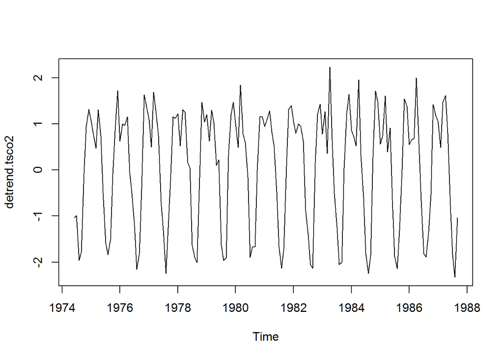

```r
# Diferencia de orden 1
detrend.tsco2 <- diff(tsco2)
plot(detrend.tsco2)
```

Como podemos ver, ahora de la serie temporal ya se ha eliminado la componente de tendecia. Una vez que hemos eliminado esta componente, volvemos a ver la nueva gráfica de la función de autocorrelación:

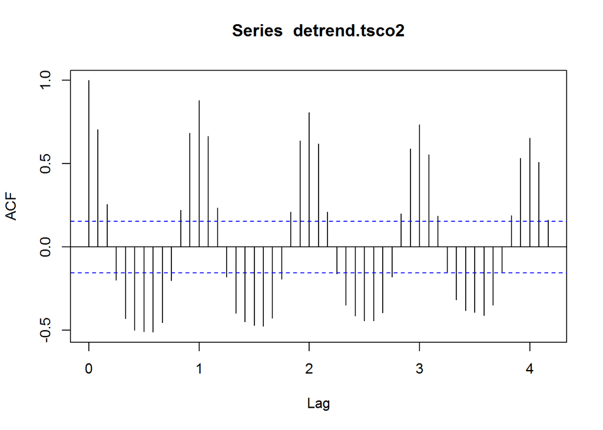

```r
# Pinta el resultados de la función de autocorrelación simple
plot(acf(detrend.tsco2,lag.max=50))
```

Aquí vemos como la serie sigue sin ser estacionaria, ya que la función de autocorrelación decrece rápidamente en los desfases regulares pero de forma lenta en los retardos estacionales (12, 24, 36 y 48), de forma que no es estacionaria en la parte estacional, además nuevamente se vuelve a ver la componente estacional de periodo 12. Esta componente estacional la vamos a mostrar más claramente extrayendo y pintando las subseries estacionales de la serie:

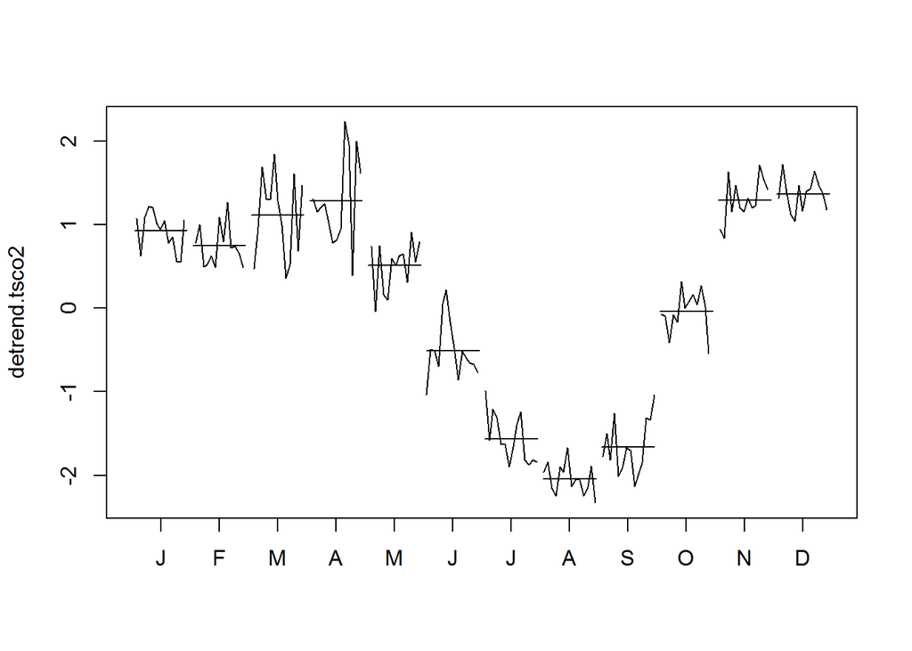

```r
# Funciones para extraer las subseries estacionales
monthplot(detrend.tsco2)
```

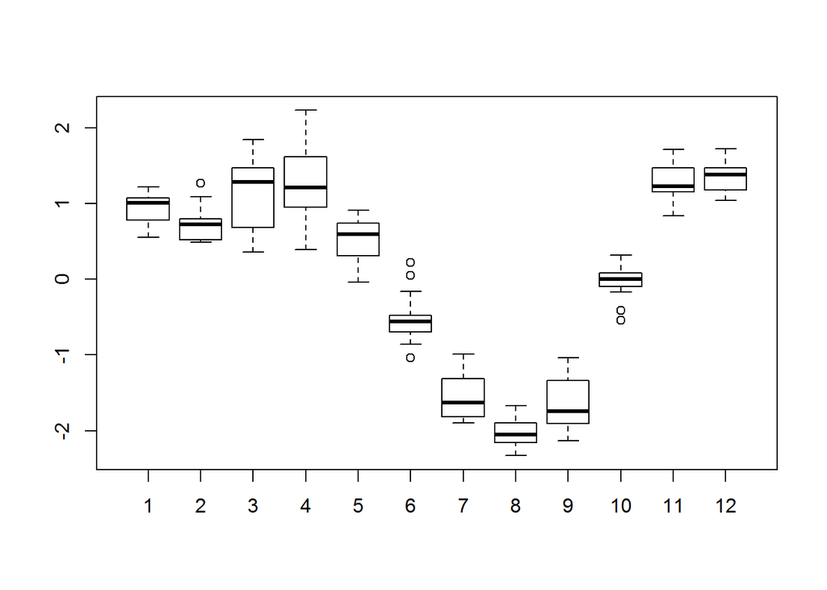

```r
boxplot(detrend.tsco2~cycle(detrend.tsco2))
```

Se puede apreciar como los picos más altos se presentan en los meses de marzo y abril, mientras que los picos más bajos en los meses de agosto y septiembre. Ahora se procede a eliminar la componente estacional, para ello se realiza una diferenciación de orden igual al periodo estacional:

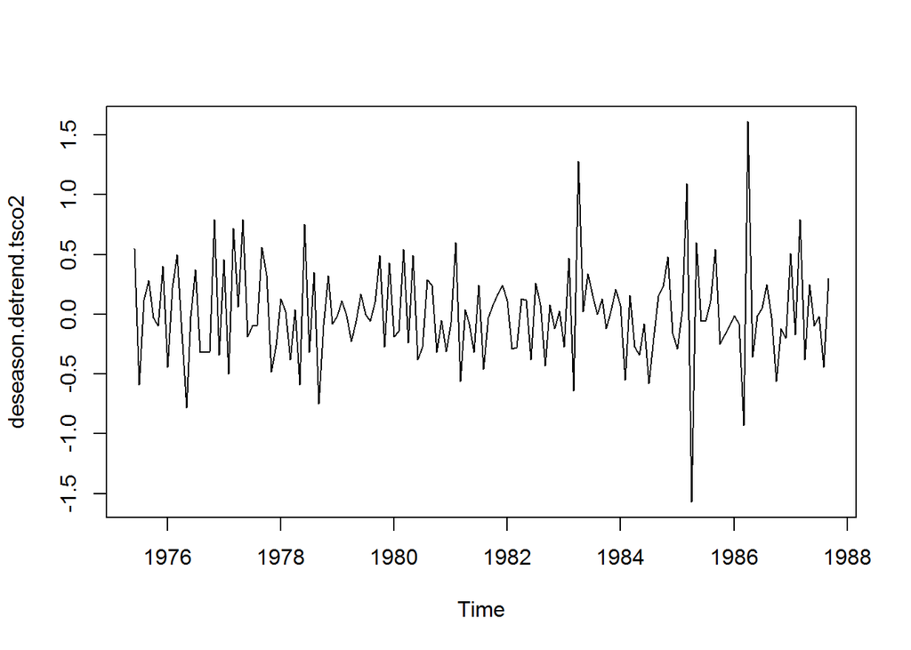

```r
# Diferencia estacional de orden 12
deseason.detrend.tsco2 <- diff(detrend.tsco2,lag=12)
plot(deseason.detrend.tsco2)
```

Una vez eliminadas tanto la componente tendencia como estacional, vemos que la serie resultante se parece bastante a una serie estacionaria, ya que parece ser constante en media y en varianza, para asegurarnos de ello vamos a aplicar sobre ella varios test de estacionalidad como son el test ADF (Dickey-Fuller Ampliado) y el test KPSS (Kwiatkowski-Phillips-Schmidt-Shin)

```r
# Test para comprobar la estacionariedad
adf <- adf.test(deseason.detrend.tsco2)
adf$p.value
```

```
## [1] 0.01
```

```r
kpss <- kpss.test(deseason.detrend.tsco2)
kpss$p.value
```

```
## [1] 0.1
```

El valor 0.01 del test ADF indica que se puede rechazar la hipótesis inicial de que la serie es no estacionaria ya que es menor que el valor umbral 0.05. Y por el otro lado el valor 0.1 del test KPSS indica que no se puede rechazar la hipótesis inicial de que la serie sí es estacionaria ya que es mayor que el umbral 0.05 y por tanto acepta la hipótesis de que la serie es estacionaria. Estos dos test nos indican que la serie es estacionaria. Además, también se puede comprobar la estacionariedad mediante la gráfica de la autocorrelación simple:

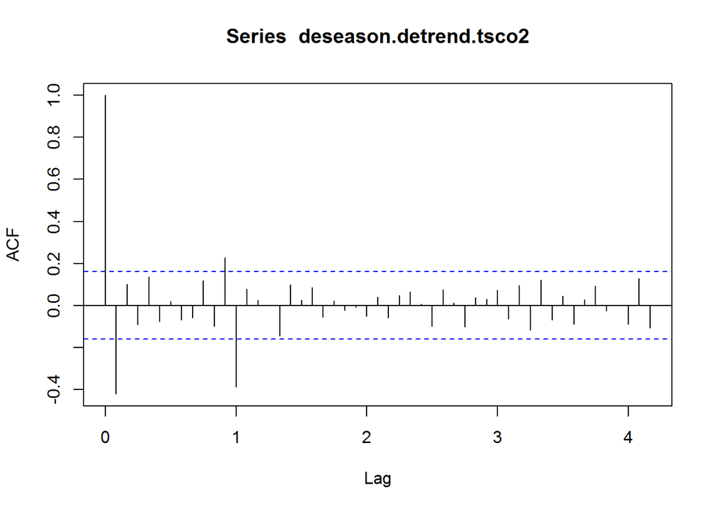

```r
# Pinta el resultados de la función de autocorrelación simple
plot(acf(deseason.detrend.tsco2,lag.max=50))
```

En la gráfica de la función de autocorrelación se puede apreciar como la caida del valor de los rezagos es exponencial, y por lo tanto se puede decir que la serie es estacionaria. Esta gráfica, junto con la gráfica de la función de autocorrelación parcial, van a ser de gran utilidad para poder intuir el posible orden de los componentes del modelo ARIMA que se pretende ajustar, y así plantear varios posibles modelos para estimar sus parámetros.

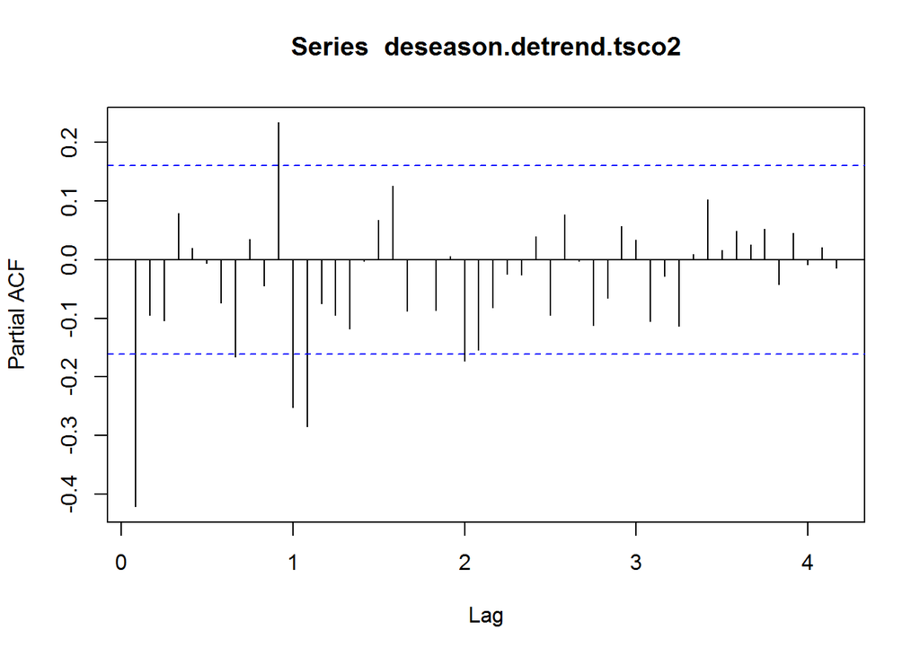

```r
# Pinta el resultados de la función de autocorrelación parcial
plot(pacf(deseason.detrend.tsco2,lag.max=50))
```

Vistas ambas gráficas, de la gráfica del ACF se puede extraer que los dos primeros rezagos significativos pueden sugerir un MA(2) no estacional, mientras que el rezago estacional significativo en el lag 12, puede sugerir un MA(1) estacional. Por otro lado, y considerando todas las posibilidades, el primer rezago significativo de la gráfica del PACF puede sugerir un AR(1) no estacional, mientras que los rezagos estacionales significativos en los lags 12 y 24 puede sugerir un AR(2) estacional (aunque pinta más de MA(1) que de AR(2)). Luego a partir de esta exploración inicial se pueden plantear varios modelos tentativos para su análisis, como lo serían los ARIMA(0,1,2)(0,1,1) o ARIMA(1,1,0)(2,1,0) deducidos, o realizando una combinación de estos como ARIMA(1,1,2)(2,1,1)) o incluso variando algunos de los componentes como puede ser con ARIMA(1,1,1)(2,1,1)) o ARIMA(1,1,2)(1,1,1)) o ARIMA(0,1,1)(0,1,1) o ARIMA(1,1,0)(1,1,0), etc.

```r
# Función que ajuste el modelo ARIMA de la serie (paquete forecast)
arima1.tsco2 <- Arima(tsco2, order=c(0,1,2), seasonal=list(order=c(0,1,1),period=12))
arima2.tsco2 <- Arima(tsco2, order=c(1,1,0), seasonal=list(order=c(2,1,0),period=12))

arima3.tsco2 <- Arima(tsco2, order=c(1,1,2), seasonal=list(order=c(2,1,1),period=12))

arima4.tsco2 <- Arima(tsco2, order=c(1,1,1), seasonal=list(order=c(2,1,1),period=12))
arima5.tsco2 <- Arima(tsco2, order=c(1,1,2), seasonal=list(order=c(1,1,1),period=12))

arima6.tsco2 <- Arima(tsco2, order=c(0,1,1), seasonal=list(order=c(0,1,1),period=12))
arima7.tsco2 <- Arima(tsco2, order=c(1,1,0), seasonal=list(order=c(1,1,0),period=12))
```

Una vez estimados los diferentes modelos, podemos recurrir a calcular los criterios AIC y BIC para comprobar cuál de ellos se ajusta mejor a los datos:

```r
#arima1.tsco2$aic
#arima2.tsco2$aic
#arima3.tsco2$aic
#arima4.tsco2$aic
#arima5.tsco2$aic
#arima6.tsco2$aic
#arima7.tsco2$aic

AIC(arima1.tsco2,arima2.tsco2,arima3.tsco2,arima4.tsco2,arima5.tsco2,arima6.tsco2,arima7.tsco2)
```

```
##              df       AIC
## arima1.tsco2  4  85.72537
## arima2.tsco2  4  93.70131
## arima3.tsco2  7  90.55929
## arima4.tsco2  6  89.02309
## arima5.tsco2  6  88.62985
## arima6.tsco2  3  83.82626
## arima7.tsco2  3 106.19086
```

```r
BIC(arima1.tsco2,arima2.tsco2,arima3.tsco2,arima4.tsco2,arima5.tsco2,arima6.tsco2,arima7.tsco2)
```

```
##              df       BIC
## arima1.tsco2  4  97.71422
## arima2.tsco2  4 105.69016
## arima3.tsco2  7 111.53978
## arima4.tsco2  6 107.00636
## arima5.tsco2  6 106.61312
## arima6.tsco2  3  92.81789
## arima7.tsco2  3 115.18250
```

Aquí se puede apreciar que los ajustes que mejor AIC y BIC presentan son aquellas que solo tienen componente de médias móviles y no tienen componente autorregresiva, siendo ARIMA(0,1,1)(0,1,1) el modelo que los test arrojan con un menor valor y por tanto con una mayor consideración. Una vez estimados los modelos y elegido el mejor de ellos, en este caso ARIMA(0,1,1)(0,1,1), se procede a validarlo. Para ello en primer lugar se grafican los correlogramas de los residuos para comprobar que son ruido blanco:

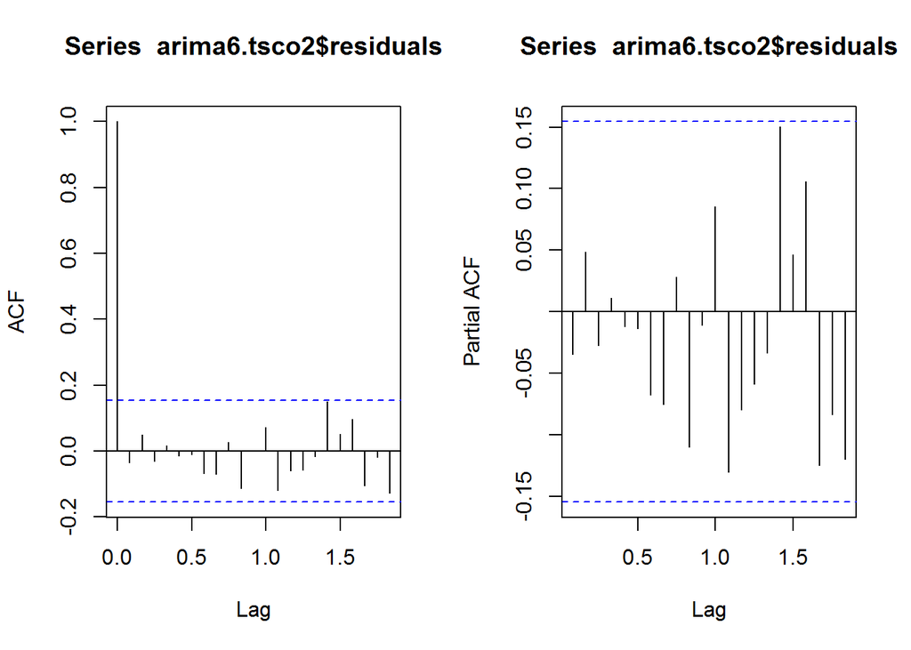

```r
# Funciones de autocorrelación simple y parcial
par(mfrow=c(1,2))
acf(arima6.tsco2$residuals)
pacf(arima6.tsco2$residuals)
```

Se puede apreciar en los correlogramas que no hay ningún rezago significativo (aparte del 0 del ACF, que es 1 por definición) que denote ningún tipo de estructura, por lo tanto podemos decir que los residuos son ruido blanco. Ahora, vamos a pintar también una serie de gráficas sobre los residuos:

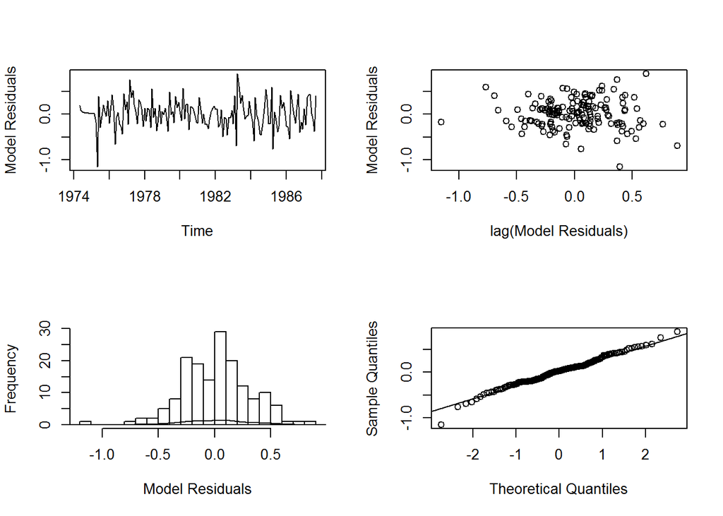

```r
par(mfrow=c(2,2))
plot(arima6.tsco2$residuals,ylab="Model Residuals",type="l")
plot(lag(arima6.tsco2$residuals,1),arima6.tsco2$residuals,ylab="Model Residuals",xlab="lag(Model Residuals)")
hist(arima6.tsco2$residuals,main="",xlab="Model Residuals",breaks=20)
lines(density(arima6.tsco2$residuals))
qqnorm(arima6.tsco2$residuals,main="")
qqline(arima6.tsco2$residuals)
```

Estas gráficas vuelven a validar el modelo elegido, ya que la primera (arriba a la izq.) muestra que los residuos son estacionarios, la segunda (arriba a la der.) muestra que los rezagos no presentan estructura (son aleatorios), mientras que la tercera (abajo izq.) y la cuarta (abajo der.) muestran que los residuos siguen una distribución normal (al ser el histograma acampanado y tener una tendencia lineal el gráfico q-q). Por último aún se pueden aplicar unos últimos tests para validar el modelo elegido, los test de Box-Pierce y Ljung-Box de aleatoriedad y el test Jarque Bera de normalidad (no se puede aplicar el test de normalidad de Shapiro-Wilk ya que es recomendado para conjuntos de datos menores de 50 observaciones):

```r
bp <- Box.test(arima6.tsco2$residuals) # Test de Box-Pierce
bp$p.value
```

```
## [1] 0.6640325
```

```r
lb <- Box.test(arima6.tsco2$residuals, type="Ljung-Box") # Test de Ljung-Box
lb$p.value
```

```
## [1] 0.6610922
```

```r
jb <- jarque.bera.test(arima6.tsco2$residuals) # Test de Jarque-Bera
jb$p.value
```

```
##  X-squared
## 0.04008699
```

```r
#shapiro.test(arima6.tsco2$residuals)
```

Aquí vemos que con respecto a los test de aleatoriedad, tanto el p-value del test de Box-Pierce como el de Ljung-Box dan un valor mayor del umbral 0.05 (0.664 y 0.6611 respectivamente), luego pasan con creces dichos test ya que no se puede rechazar la hipótesis inicial de que los datos son aleatorios. Y por el otro lado, el test de normalidad de Jarque-Bera no pasa el umbral de 0.05 y por lo tanto se puede rechazar la hipótesis de que los datos están normalmente distribuidos. Como las gráficas sí parecen mostrar que los datos están normalmente distribuidos, se van a realizar otros test de normalidad para contrastar los resultados del test Jarque-Bera, en este caso el de Kolmogorov-Smirnov y Lilliefors (que es una mejora de este):

```r
library(fBasics)
library(nortest)

ks <- ksnormTest(arima6.tsco2$residuals) # Test de Kolmogorov-Smirnov
ks
```

```
##
## Title:
##  One-sample Kolmogorov-Smirnov test
##
## Test Results:
##   STATISTIC:
##     D: 0.2786
##   P VALUE:
##     Alternative Two-Sided: 2.809e-11
##     Alternative      Less: 1.404e-11
##     Alternative   Greater: 2.374e-10
##
## Description:
##  Wed Feb 01 18:43:02 2017 by user: Kuko
```

```r
#jarqueberaTest(arima6.tsco2$residuals)
#shapiroTest(arima6.tsco2$residuals)
#dagoTest(arima6.tsco2$residuals)
#jbTest(arima6.tsco2$residuals)
l <- lillie.test(arima6.tsco2$residuals) # Test de Lilliefors
l$p.value
```

```
## [1] 0.2340749
```

```r
# Función que estima el mejor modelo ARIMA
auto.arima(tsco2,stepwise=FALSE, approximation=FALSE)
```

```
## Series: tsco2
## ARIMA(1,0,1)(0,1,1)[12] with drift
##
## Coefficients:
##          ar1      ma1     sma1   drift
##       0.8999  -0.4391  -0.7686  0.1193
## s.e.  0.0479   0.0885   0.0930  0.0034
##
## sigma^2 estimated as 0.09903:  log likelihood=-35.58
## AIC=81.16   AICc=81.58   BIC=96.18
```

En este caso la función sugiere que el mejor modelo que representa a la serie sería un ARIMA(1,0,1)(0,1,1) con tendencia, y que arroja un AIC de 81.16, siendo algo mejor al modelo que anteriormente habíamos visto, 83.83. El modelo sugerido por la función *auto.arima*, al especificarse que tiene tendencia, es equivalente a un ARIMA(1,1,1)(0,1,1), que únicamente añade una componente autorregresiva al modelo que en un principio hemos estimado (algo que ya se intuyó en el análisis visual):

```r
# Función que ajuste el modelo ARIMA de la serie (paquete forecast)
arima8.tsco2 <- Arima(tsco2, order=c(1,1,1), seasonal=list(order=c(0,1,1),period=12))

#arima8.tsco2 <- Arima(tsco2, order=c(1,0,1), seasonal=list(order=c(0,1,1),period=12),include.drif=TRUE)

arima8.tsco2$aic
```

```
## [1] 85.70159
```

Pero al estimarlo vemos que su AIC es de 85.7, que es mayor que el que teníamos anteriormente, 83.83, y mucho mayor también que el prometido 81.16 en *auto.arima*. Luego ¿quiere esta incoherencia decir que la función *auto.arima* se equivoca?. No, y no es ninguna incoherencia, ya que la función *Arima* con la opción de tendencia, ajusta dicha tendencia mediante una regresión lineal, mientras que con la componente integrada I(d) de ARIMA se elimina la tendencia mediante diferenciación. Luego esto nos indica que parece que el ajuste de la tendencia mediante una modelo lineal obtiene mejores resultados que diferenciando. Por lo tanto, vamos a ajustar la tendencia de esta manera:

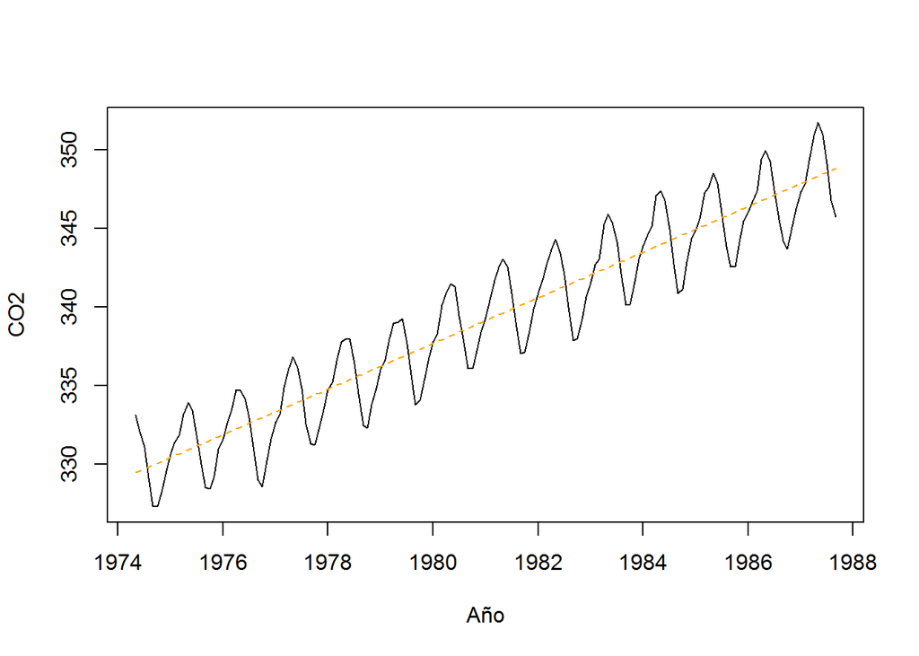

```r
# Función que ajusta un modelo lineal
tiempo <- time(tsco2)
#tiempo <- 1:(length(tsco2))
lm.tsco2 <- lm(tsco2~tiempo) #Modelo lineal

plot(tsco2, ylab="CO2", xlab="Año")
lines(c(time(tsco2)),lm.tsco2$fitted.values,col="orange",lty="dashed")
```

```r
newtsco2 <- tsco2-lm.tsco2$fitted.values # Eliminación de la tendencia
```

En las siguientes gráficas comparativas se puede apreciar como la serie temporal sin tendencia difiere si se elimina la tendencia por diferenciación, o tras ajustar un modelo lineal:

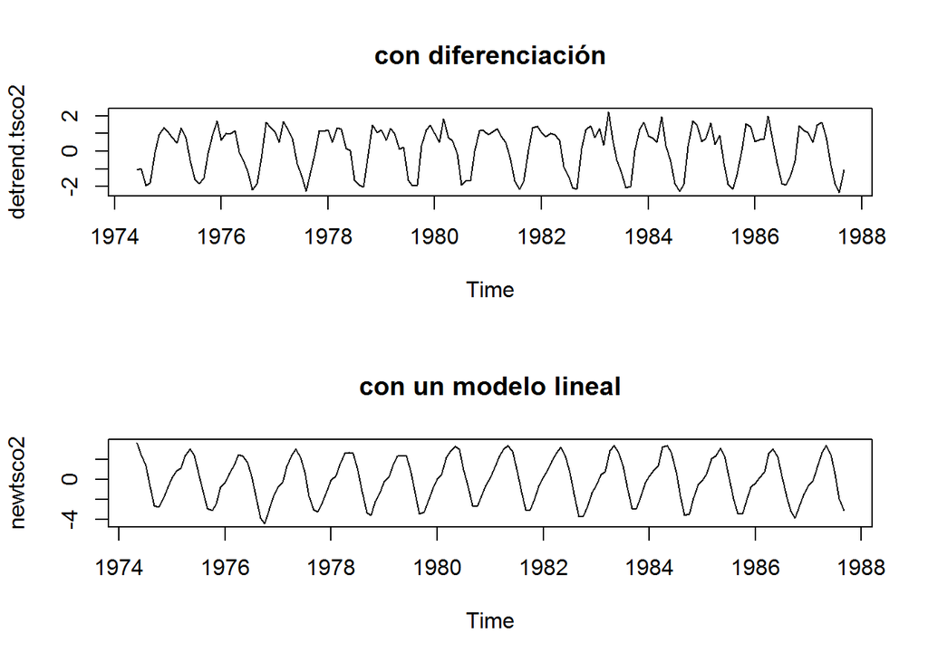

```r
par(mfrow=c(2,1))
plot(detrend.tsco2, main="con diferenciación")
plot(newtsco2, main="con un modelo lineal")
```

Como ya vimos que la serie sin tendencia necesitaba además una diferenciación estacional, y ya sabemos también los órdenes del modelo, pues ajustamos el nuevo modelo ARIMA sobre la nueva serie sin tendencia en lugar de la original:

```r
# Función que ajuste el modelo ARIMA de la serie (paquete forecast)
arima9.tsco2 <- Arima(newtsco2, order=c(1,0,1), seasonal=list(order=c(0,1,1),period=12))

arima9.tsco2$aic
```

```
## [1] 79.4011
```

Una vez ajustado el modelo vemos que incluso mejora el AIC del modelo sugerido por la función *auto.arima* con tendencia incluida, ya que ahora es de 79.4, mejor que el 81.16. Volvemos a ver los correlogramas de los residuos para cerciorarnos de que vuelven a ser ruido blanco:

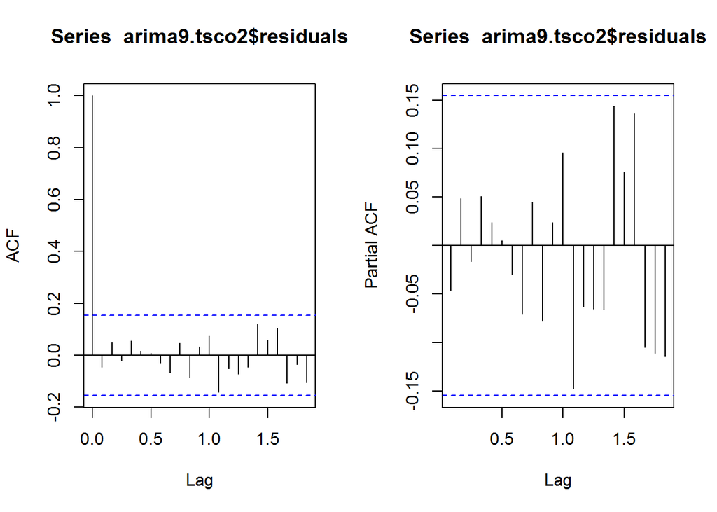

```r
# Funciones de autocorrelación simple y parcial
par(mfrow=c(1,2))
acf(arima9.tsco2$residuals)
pacf(arima9.tsco2$residuals)
```

Volvemos a pintar las gráficas de los residuos para ver nuevamente que es ruido blanco, aleatorio y normalmente distribuido:

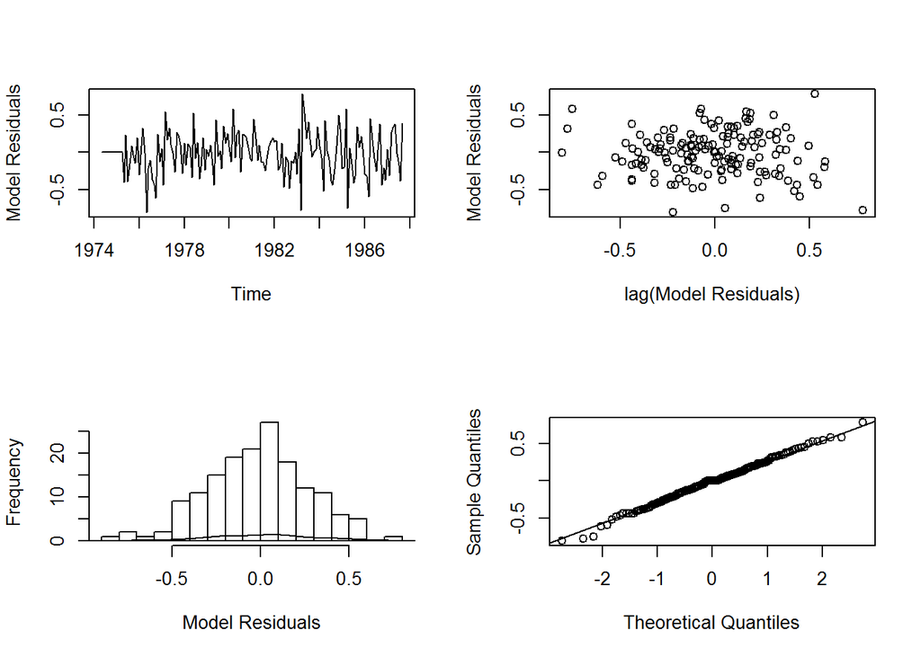

```r
par(mfrow=c(2,2))
plot(arima9.tsco2$residuals,ylab="Model Residuals",type="l")
plot(lag(arima9.tsco2$residuals,1),arima9.tsco2$residuals,ylab="Model Residuals",xlab="lag(Model Residuals)")
hist(arima9.tsco2$residuals,main="",xlab="Model Residuals",breaks=20)
lines(density(arima6.tsco2$residuals))
qqnorm(arima9.tsco2$residuals,main="")
qqline(arima9.tsco2$residuals)
```

Y volvemos a pasar los test de aleatoriedad y normalidad sobre los residuos:

```r
bp <- Box.test(arima9.tsco2$residuals)
bp$p.value
```

```
## [1] 0.5585488
```

```r
lb <- Box.test(arima9.tsco2$residuals, type="Ljung-Box")
lb$p.value
```

```
## [1] 0.5548841
```

```r
jb <- jarque.bera.test(arima9.tsco2$residuals)
jb$p.value
```

```
## X-squared
## 0.7951253
```

```r
ks <- ksnormTest(arima9.tsco2$residuals)
ks
```

```
##
## Title:
##  One-sample Kolmogorov-Smirnov test
##
## Test Results:
##   STATISTIC:
##     D: 0.2831
##   P VALUE:
##     Alternative Two-Sided: 1.241e-11
##     Alternative      Less: 8.946e-12
##     Alternative   Greater: 6.204e-12
##
## Description:
##  Wed Feb 01 18:46:52 2017 by user: Kuko
```

```r
l <- lillie.test(arima9.tsco2$residuals)
l$p.value
```

```
## [1] 0.3139406
```

#### Predicción de la serie

Para predecir la serie a futuro con el modelo ARIMA ajustado, se emplea la función *forecast*. Se realiza una predicción de 1 y 3 años:

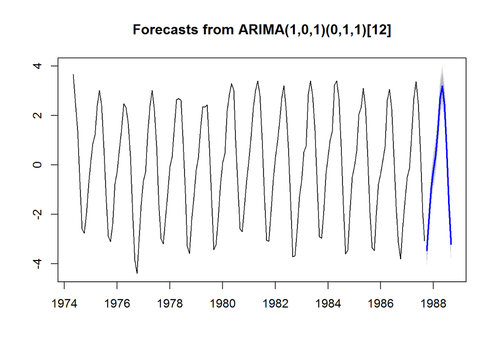

```r
forecast.tsco2 <- forecast(arima9.tsco2, 12)
plot(forecast.tsco2)
```

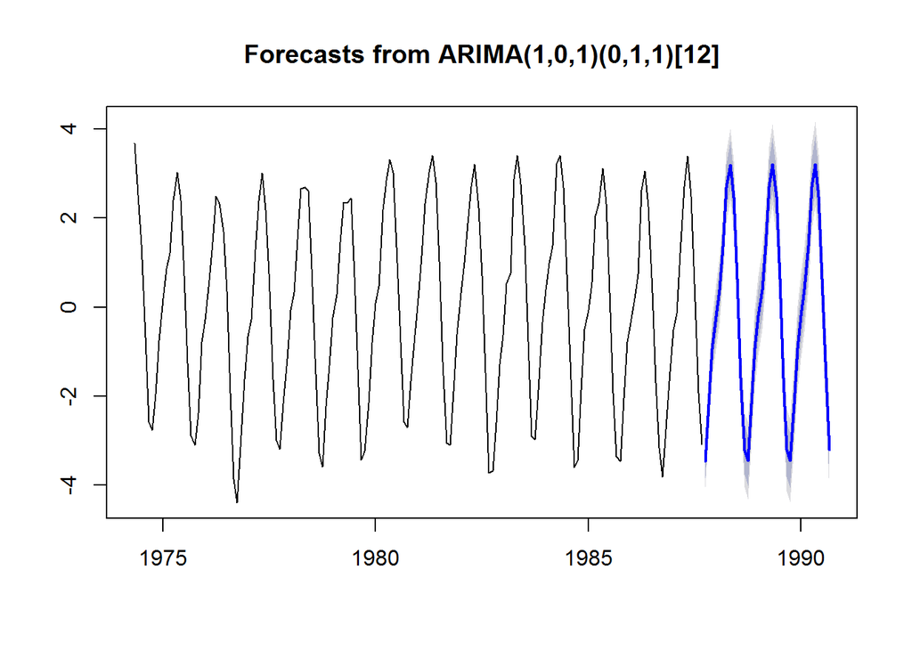

```r
forecast.tsco2 <- forecast(arima9.tsco2, 36)
plot(forecast.tsco2)
```

Se puede apreciar como el intervalo de predicción es muy pequeño, pero si se predicen 3 años en lugar de 1, se aprecia como ese intervalo aumenta.

Pero esta predicción no está realizada sobre la serie original, sino sobre la serie sin tendencia. Luego ahora a partir de la predicción obtenida de la serie sin tendencia, se debe de añadir la predicción de la tendencia en el perido de predicción para reconstruir la serie original. Por lo tanto se debe de predecir la tendencia de la serie para los tres años siguientes (periodo de predicción elegido), y a esa tendencia se sumarán los valores predichos por el modelo ARIMA sobre la serie sin tendencia. Por último, se pintan también junto con la predicción de la serie los intervalos de predicción del 95% y 80%:

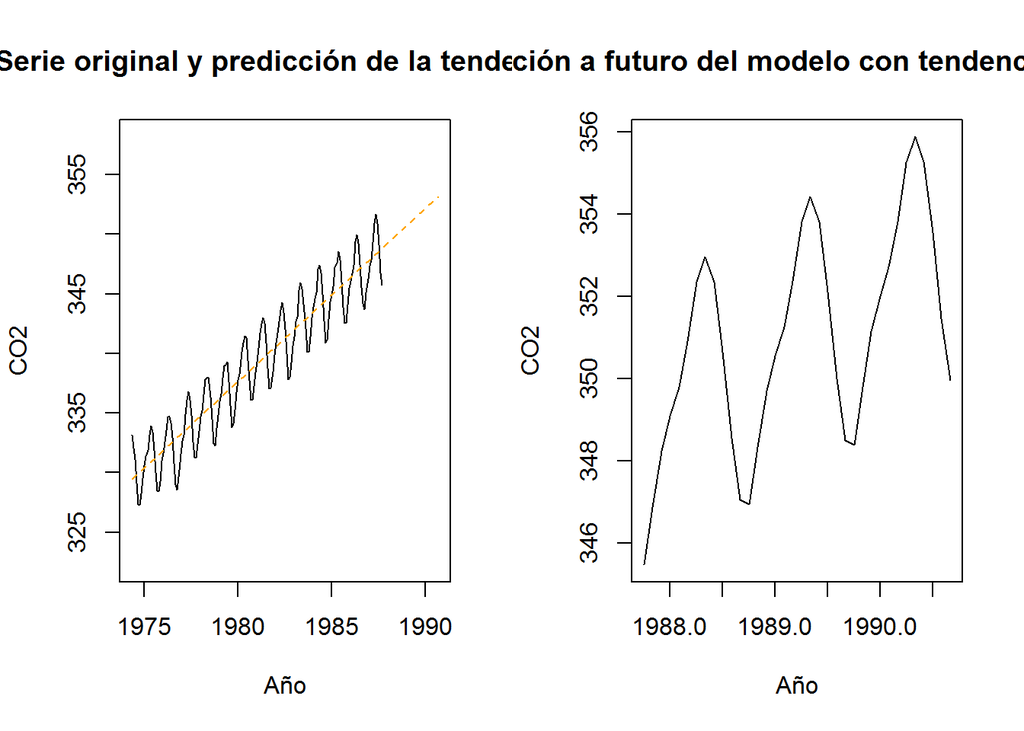

```r
# Periodo de tiempo de la predicción
tiempo <- time(forecast.tsco2$mean)
#tiempo <- ((length(tsco2))+1):((length(tsco2))+36)

# Predicción de la tendencia ajustada por el modelo lineal
lm.predict.tsco2<-predict(lm.tsco2,newdata=tiempo)
#lm.predict.tsco2<-predict(lm.tsco2,newdata=data.frame(tiempo))

# Pinta la serie original más la predicción de la tendencia, y la predicción futura con la tendencia añadida
par(mfrow=c(1,2))
plot(tsco2, type="l", ylab="CO2", xlab="Año", main="Serie original y predicción de la tendencia", xlim=c(min(time(tsco2)),max(time(forecast.tsco2$mean))), ylim=c(min(co2$CO2)-5,max(c(lm.tsco2$fitted.values,lm.predict.tsco2))+5))
lines(c(time(tsco2),time(forecast.tsco2$mean)),c(lm.tsco2$fitted.values,lm.predict.tsco2),col="orange",lty="dashed")
plot(forecast.tsco2$mean+lm.predict.tsco2,ylab="CO2", xlab="Año", main="Predicción a futuro del modelo con tendencia añadida")
```

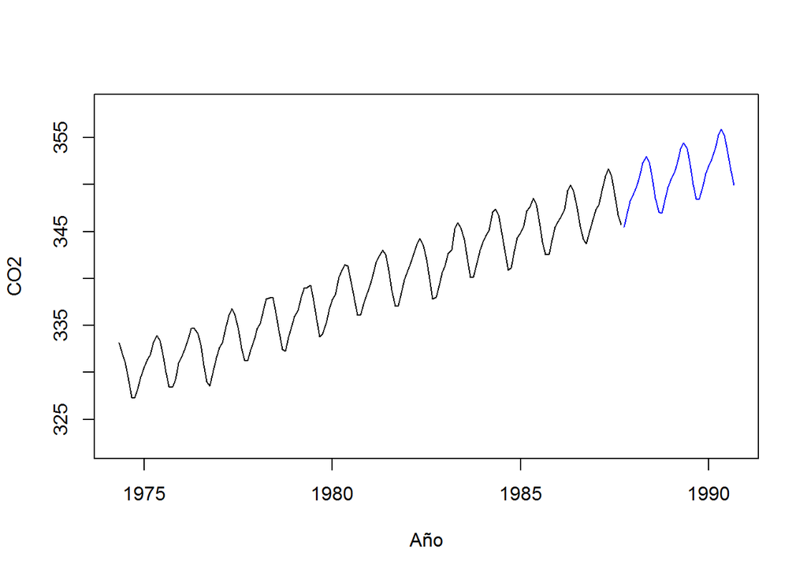

```r
#par(mfrow=c(2,1))
#plot(co2$CO2, type="l", ylab="CO2", xlab="Año", xlim=c(0,length(co2$CO2)+36), #ylim=c(min(co2$CO2)-5,max(c(lm.tsco2$fitted.values,lm.predict.tsco2))+5))
#lines(c(1:(length(tsco2)+36)),c(lm.tsco2$fitted.values,lm.predict.tsco2),col="orange",lty="dashed")
#plot(forecast.tsco2$mean+lm.predict.tsco2)

# Serie original y predicción
par(mfrow=c(1,1))
plot(tsco2, type="l", ylab="CO2", xlab="Año", xlim=c(min(time(tsco2)),max(time(forecast.tsco2$mean))), ylim=c(min(co2$CO2)-5,max(c(lm.tsco2$fitted.values,lm.predict.tsco2))+5))
lines(c(time(forecast.tsco2$mean)),c(forecast.tsco2$mean+lm.predict.tsco2),col="blue")
```

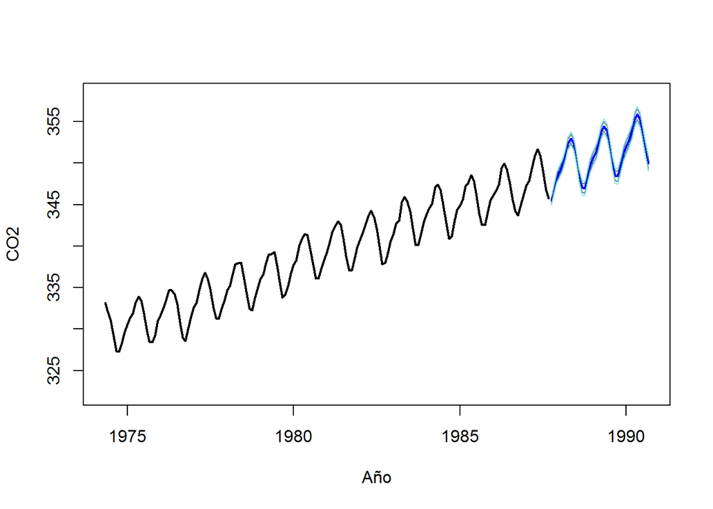

```r
#plot(co2$CO2, type="l", ylab="CO2", xlab="Año", xlim=c(0,length(co2$CO2)+36), ylim=c(min(co2$CO2)-5,max(c(lm.tsco2$fitted.values,lm.predict.tsco2))+5))
#lines(c(((length(tsco2))+1):((length(tsco2))+36)),c(forecast.tsco2$mean+lm.predict.tsco2),col="blue")

# Serie original y predición, con intervalos del 95% y 80%
plot(tsco2, type="l", ylab="CO2", xlab="Año", lwd=2, xlim=c(min(time(tsco2)),max(time(forecast.tsco2$mean))), ylim=c(min(co2$CO2)-5,max(c(lm.tsco2$fitted.values,lm.predict.tsco2))+5))
lines(c(time(forecast.tsco2$mean)),c(forecast.tsco2$mean+lm.predict.tsco2),lwd=2,col="blue")
lines(c(time(forecast.tsco2$mean)),c(forecast.tsco2$upper[,1]+lm.predict.tsco2),col="cadetblue4")
lines(c(time(forecast.tsco2$mean)),c(forecast.tsco2$lower[,1]+lm.predict.tsco2),col="cadetblue4")
lines(c(time(forecast.tsco2$mean)),c(forecast.tsco2$upper[,2]+lm.predict.tsco2),col="cadetblue2")
lines(c(time(forecast.tsco2$mean)),c(forecast.tsco2$lower[,2]+lm.predict.tsco2),col="cadetblue2")
```